# Variable Selection Question 2

Mary Fisher

February 28, 2020

#### Research Question: Can we predict giant kelp size and abundance from oceanographic conditions and herbivore abundance (predictor)?

**Response variables:** Giant kelp mean abundance, max abundance; Giant kelp mean size, maximum size.

**Predictor variables:**

1. Urchin abundance: Sea urchins are herbivores, and in large numbers (also called “herds”) can decimate kelp forests. We have three measures of urchin abundance - red urchin abundance, purple urchin abundance, and urchin abundance across all species.
2. Water chemistry: Like any algae / plant, kelp requires nutrients to grow. We have measurements for the following nutrients: nitrogen, ammonia, urea, and phosphorus. We also have chlorophyl concentrations, which is a general index of primary productivity.
3. Water temperature: All species have a thermal range, or a range of temperatures, at which they grow best; the degree of variability in temperature can also have an impact on growth. With kelp forest loss from recent marine heatwaves and long-term warming, there has been much interest in whether kelp are impacted by an absolute temperature threshold, or by the degree of variability in temperature. We have mean summer and mean winter temperatures, and variation in summer and mean winter temperatures.

Read in data

```r
mydat <- read.csv(here::here("data","kelp_prediction_data_complete.csv")) %>%
  clean_names() %>%
  dplyr::select(-target_depth_m)
head(mydat)
```

```
##   year month site transect mapy_mean_abund mapy_max_abund mapy_mean_size
## 1 2002     8 CARP        1       0.6245833            0.8       15.48148
## 2 2002     8 CARP        1       0.6245833            0.8       15.48148
## 3 2002     8 CARP        1       0.6245833            0.8       15.48148
## 4 2002     8 CARP        1       0.6245833            0.8       15.48148
## 5 2002     8 CARP        2       0.0000000            0.0             NA
## 6 2002     8 CARP        2       0.0000000            0.0             NA
##   mapy_max_size franciscanus_abundance purpuratus_abundance urchin_abundance
## 1            30                      9                   92              101
## 2            30                      9                   92              101
## 3            30                      9                   92              101
## 4            30                      9                   92              101
## 5            NA                      2                  144              146
## 6            NA                      2                  144              146
##   max_no2_no3 max_po4 max_tchl mean_no2_no3  mean_po4 mean_tchl
## 1      1.5936  0.4613  10.2905      1.00904 0.3128571  3.112844
## 2      1.5936  0.4613  10.2905      1.00904 0.3128571  3.112844
## 3      1.5936  0.4613  10.2905      1.00904 0.3128571  3.112844
## 4      1.5936  0.4613  10.2905      1.00904 0.3128571  3.112844
## 5      1.5936  0.4613  10.2905      1.00904 0.3128571  3.112844
## 6      1.5936  0.4613  10.2905      1.00904 0.3128571  3.112844
##   summer_mean_temp summer_var_temp winter_mean_temp winter_var_temp
## 1         15.08623       0.9835033         15.40677       0.5308104
## 2         15.08623       0.9835033         15.42255       0.5327413
## 3         15.09231       0.9743531         15.40677       0.5308104
## 4         15.09231       0.9743531         15.42255       0.5327413
## 5         15.08623       0.9835033         15.40677       0.5308104
## 6         15.08623       0.9835033         15.42255       0.5327413
```

## Multicolinearity / Predictor Selection

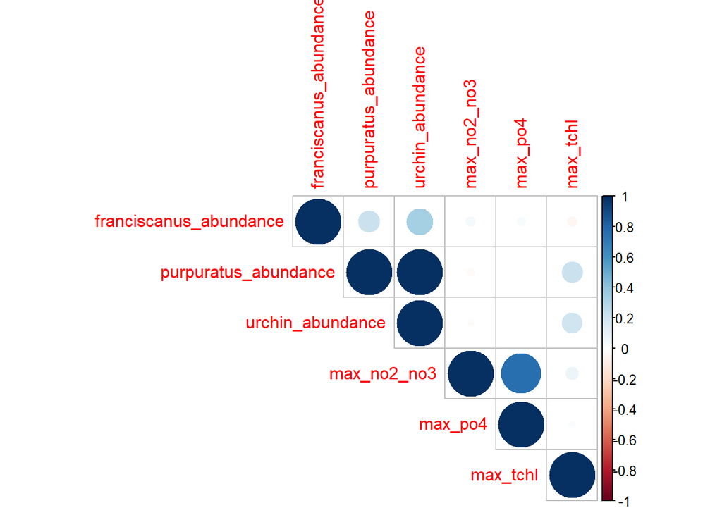

```r
corrplot(cor(mydat[,9:14],use="complete.obs"), type="upper")
```

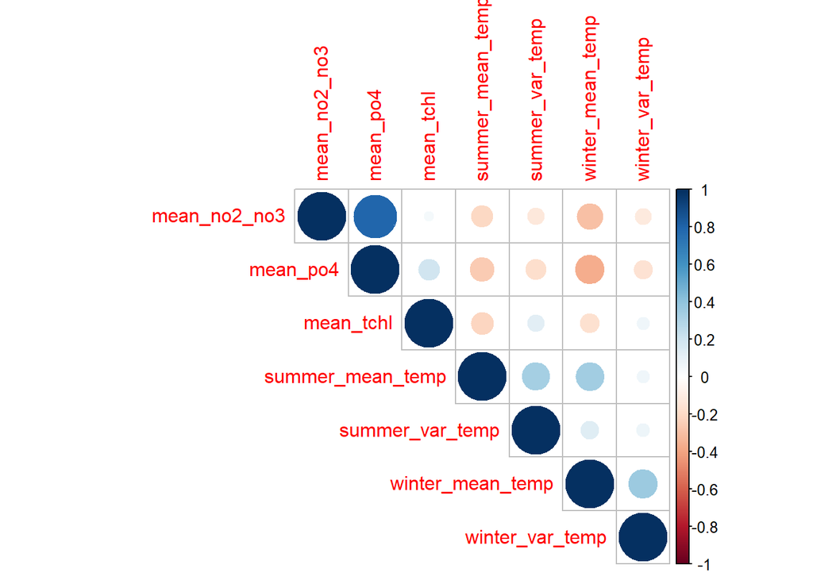

```r
corrplot(cor(mydat[,15:21], use="complete.obs"), type="upper")
```

We have three variables that quantify urchin abundance - we’ll just work with total abundance (`urchin_abundance`). Nitrogen and phosphorus are correlated, so we’ll choose to look at nitrogen (`no2_no3`) because nitrogen is a key nutrient required for kelp growth. We also focused on mean seasonal temperatures, rather than the variability in seasonal temperature.

```r
lmdat <- mydat %>%
  dplyr::select(-purpuratus_abundance,-franciscanus_abundance, -max_po4, -mean_po4)
```

## Model Selection & Diagnostics

### Size of Giant Kelp

#### Fit model

```r
n <- dim(lmdat)[1]
fit.a <- lm(mapy_mean_size ~ urchin_abundance+site+
              mean_no2_no3+mean_tchl+
              summer_mean_temp+winter_mean_temp+
              mean_no2_no3*summer_mean_temp+mean_tchl*summer_mean_temp +
              site*summer_mean_temp,data=lmdat)
scp <- list(lower = ~ 1,
           upper = ~ urchin_abundance+site+
              mean_no2_no3+mean_tchl+
              summer_mean_temp+winter_mean_temp+
              mean_no2_no3*summer_mean_temp+mean_tchl*summer_mean_temp+site*summer_mean_temp)

fit.f <- step(fit.a, scope = scp, direction = "backward",  k = log(n))
```

```
## Start:  AIC=28271.03
## mapy_mean_size ~ urchin_abundance + site + mean_no2_no3 + mean_tchl +
##     summer_mean_temp + winter_mean_temp + mean_no2_no3 * summer_mean_temp +
##     mean_tchl * summer_mean_temp + site * summer_mean_temp
##
##                                 Df Sum of Sq     RSS   AIC
## - winter_mean_temp               1       377 1451100 28264
## - mean_no2_no3:summer_mean_temp  1      2214 1452936 28270
## <none>                                       1450722 28271
## - mean_tchl:summer_mean_temp     1      2579 1453301 28271
## - site:summer_mean_temp          4     13764 1464487 28283
## - urchin_abundance               1     49047 1499769 28427
##
## Step:  AIC=28263.64
## mapy_mean_size ~ urchin_abundance + site + mean_no2_no3 + mean_tchl +
##     summer_mean_temp + mean_no2_no3:summer_mean_temp + mean_tchl:summer_mean_temp +
##     site:summer_mean_temp
##
##                                 Df Sum of Sq     RSS   AIC
## - mean_no2_no3:summer_mean_temp  1      2330 1453429 28263
## <none>                                       1451100 28264
## - mean_tchl:summer_mean_temp     1      2801 1453900 28265
## - site:summer_mean_temp          4     13689 1464789 28275
## - urchin_abundance               1     48761 1499860 28419
##
## Step:  AIC=28262.91
## mapy_mean_size ~ urchin_abundance + site + mean_no2_no3 + mean_tchl +
##     summer_mean_temp + mean_tchl:summer_mean_temp + site:summer_mean_temp
##
##                              Df Sum of Sq     RSS   AIC
## <none>                                    1453429 28263
## - mean_no2_no3                1      4320 1457749 28269
## - mean_tchl:summer_mean_temp  1      7062 1460491 28278
## - site:summer_mean_temp       4     15796 1469225 28282
## - urchin_abundance            1     49828 1503258 28421
```

```r
n <- dim(lmdat)[1]
fit.e <- lm(mapy_mean_size ~ 1,data=lmdat)
fit.a <- lm(mapy_mean_size ~ urchin_abundance+site+
              mean_no2_no3+mean_tchl+
              summer_mean_temp+winter_mean_temp+
              mean_no2_no3*summer_mean_temp+mean_tchl*summer_mean_temp+
              site*summer_mean_temp,data=lmdat)
scp <- list(lower = ~ 1,
           upper = ~ urchin_abundance+site+
              mean_no2_no3+mean_tchl+
              summer_mean_temp+winter_mean_temp+
              mean_no2_no3*summer_mean_temp+mean_tchl*summer_mean_temp)

fit.f <- step(fit.e, scope = scp, direction = "forward",  k = log(n))
```

```
## Start:  AIC=31072.93
## mapy_mean_size ~ 1
##
##                    Df Sum of Sq     RSS   AIC
## + site              4   1070040 1552236 28511
## + urchin_abundance  1    401000 2221276 30260
## + mean_tchl         1     27532 2594744 31029
## + winter_mean_temp  1     17302 2604974 31049
## + mean_no2_no3      1     14650 2607626 31054
## <none>                          2622276 31073
## + summer_mean_temp  1        50 2622226 31082
##
## Step:  AIC=28510.56
## mapy_mean_size ~ site
##
##                    Df Sum of Sq     RSS   AIC
## + urchin_abundance  1     66434 1485802 28303
## + summer_mean_temp  1     15918 1536318 28468
## + mean_no2_no3      1      7220 1545015 28496
## <none>                          1552236 28511
## + mean_tchl         1      1235 1551001 28515
## + winter_mean_temp  1       822 1551413 28517
##
## Step:  AIC=28302.58
## mapy_mean_size ~ site + urchin_abundance
##
##                    Df Sum of Sq     RSS   AIC
## + summer_mean_temp  1    5819.7 1479982 28292
## + mean_no2_no3      1    5149.3 1480652 28294
## <none>                          1485802 28303
## + mean_tchl         1    1416.0 1484386 28307
## + winter_mean_temp  1       5.4 1485796 28311
##
## Step:  AIC=28291.82
## mapy_mean_size ~ site + urchin_abundance + summer_mean_temp
##
##                    Df Sum of Sq     RSS   AIC
## + mean_tchl         1    4127.9 1475854 28287
## + mean_no2_no3      1    3402.5 1476580 28289
## <none>                          1479982 28292
```

[output cut: 15 more lines]

```
##
##                                 Df Sum of Sq     RSS   AIC
## + mean_no2_no3:summer_mean_temp  1    6481.4 1465059 28268
## <none>                                       1471540 28281
## + mean_tchl:summer_mean_temp     1    2315.0 1469225 28282
## + winter_mean_temp               1     826.7 1470713 28287
##
## Step:  AIC=28267.67
## mapy_mean_size ~ site + urchin_abundance + summer_mean_temp +
##     mean_tchl + mean_no2_no3 + summer_mean_temp:mean_no2_no3
##
##                              Df Sum of Sq     RSS   AIC
## <none>                                    1465059 28268
## + winter_mean_temp            1    368.10 1464691 28275
## + mean_tchl:summer_mean_temp  1    270.29 1464789 28275
```

Final model: `mapy_mean_size ~ site + urchin_abundance + summer_mean_temp + mean_tchl + mean_no2_no3 + summer_mean_temp:mean_no2_no3`

```r
summary(fit.f)
```

```
##
## Call:
## lm(formula = mapy_mean_size ~ site + urchin_abundance + summer_mean_temp +
##     mean_tchl + mean_no2_no3 + summer_mean_temp:mean_no2_no3,
##     data = lmdat)
##
## Residuals:
##     Min      1Q  Median      3Q     Max
## -49.385  -9.698  -1.044   8.695  83.212
##
## Coefficients:
##                                 Estimate Std. Error t value Pr(>|t|)
## (Intercept)                    42.671495   5.811935   7.342 2.45e-13 ***
## siteAQUE                       31.290050   1.213377  25.788  < 2e-16 ***
## siteCARP                       -9.375142   1.203656  -7.789 8.18e-15 ***
## siteMOHK                       11.297576   1.256669   8.990  < 2e-16 ***
## siteNAPL                       -6.592328   1.007018  -6.546 6.49e-11 ***
## urchin_abundance               -0.050024   0.003754 -13.327  < 2e-16 ***
## summer_mean_temp               -0.268528   0.346577  -0.775    0.438
## mean_tchl                       0.465216   0.113175   4.111 4.01e-05 ***
## mean_no2_no3                  -11.107458   2.242566  -4.953 7.55e-07 ***
## summer_mean_temp:mean_no2_no3   0.648157   0.138605   4.676 3.00e-06 ***
## ---
## Signif. codes:  0 '***' 0.001 '**' 0.01 '*' 0.05 '.' 0.1 ' ' 1
##
## Residual standard error: 17.22 on 4943 degrees of freedom
##   (927 observations deleted due to missingness)
## Multiple R-squared:  0.4413, Adjusted R-squared:  0.4403
## F-statistic: 433.8 on 9 and 4943 DF,  p-value: < 2.2e-16
```

How does RSE / R squared compare to full model

```r
summary(fit.a)
```

```
##
## Call:
## lm(formula = mapy_mean_size ~ urchin_abundance + site + mean_no2_no3 +
##     mean_tchl + summer_mean_temp + winter_mean_temp + mean_no2_no3 *
##     summer_mean_temp + mean_tchl * summer_mean_temp + site *
##     summer_mean_temp, data = lmdat)
##
## Residuals:
##     Min      1Q  Median      3Q     Max
## -49.080  -9.719  -1.168   8.874  81.899
##
## Coefficients:
##                                 Estimate Std. Error t value Pr(>|t|)
## (Intercept)                    86.797443  13.242925   6.554 6.16e-11 ***
## urchin_abundance               -0.048559   0.003759 -12.920  < 2e-16 ***
## siteAQUE                       60.927574  16.854244   3.615 0.000303 ***
## siteCARP                      -23.627723  14.561464  -1.623 0.104735
## siteMOHK                      -17.277933  15.573639  -1.109 0.267297
## siteNAPL                      -51.786506  12.390244  -4.180 2.97e-05 ***
## mean_no2_no3                   -7.670981   2.544534  -3.015 0.002586 **
## mean_tchl                      -6.196255   2.250042  -2.754 0.005912 **
## summer_mean_temp               -2.898890   0.844811  -3.431 0.000605 ***
## winter_mean_temp               -0.198551   0.175239  -1.133 0.257257
## mean_no2_no3:summer_mean_temp   0.432688   0.157645   2.745 0.006079 **
## mean_tchl:summer_mean_temp      0.416014   0.140437   2.962 0.003068 **
## siteAQUE:summer_mean_temp      -1.838804   1.070186  -1.718 0.085821 .
## siteCARP:summer_mean_temp       0.970025   0.906970   1.070 0.284887
## siteMOHK:summer_mean_temp       1.855199   0.970481   1.912 0.055982 .
## siteNAPL:summer_mean_temp       2.892110   0.788135   3.670 0.000246 ***
## ---
## Signif. codes:  0 '***' 0.001 '**' 0.01 '*' 0.05 '.' 0.1 ' ' 1
##
## Residual standard error: 17.14 on 4937 degrees of freedom
##   (927 observations deleted due to missingness)
## Multiple R-squared:  0.4468, Adjusted R-squared:  0.4451
## F-statistic: 265.8 on 15 and 4937 DF,  p-value: < 2.2e-16
```

#### Model Diagnostics

It looks like this model violates the normality assumption, but there don’t appear to be any outliers. The TA plot looks a little weird.

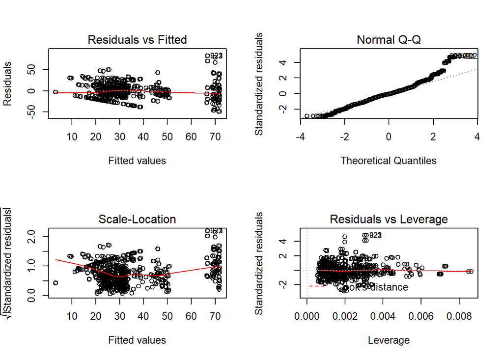

```r
par(mfrow=c(2,2))
plot(fit.f)
```

Here is the right tail on the residuals:

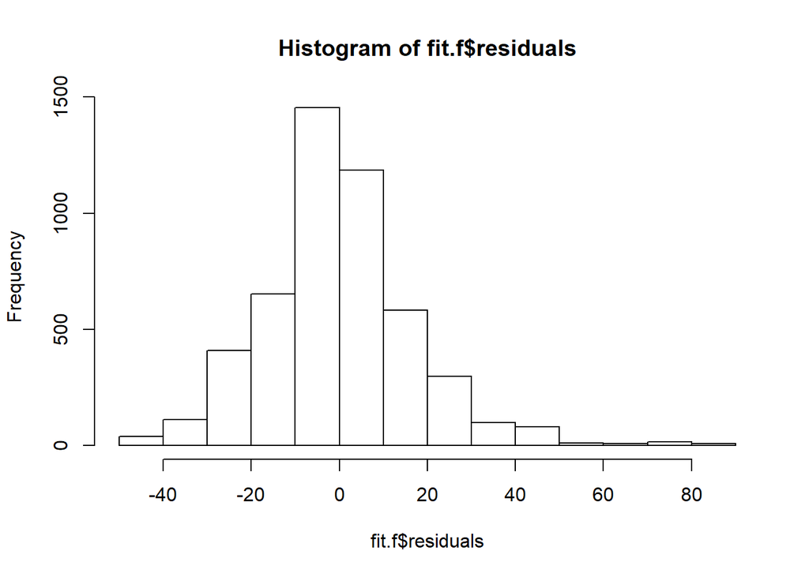

```r
hist(fit.f$residuals)
```

### Abundance of Giant Kelp

#### Fit Model

```r
n <- dim(lmdat)[1]
fit.abund.e <- lm(mapy_mean_abund ~ 1,data=lmdat)
fit.abund.a <- lm(mapy_mean_abund ~ urchin_abundance+site+
              mean_no2_no3+mean_tchl+
              summer_mean_temp+winter_mean_temp+
              mean_no2_no3*summer_mean_temp+mean_tchl*summer_mean_temp+
              site*summer_mean_temp,data=lmdat)
scp <- list(lower = ~ 1,
           upper = ~ urchin_abundance+site+
              mean_no2_no3+mean_tchl+
              summer_mean_temp+winter_mean_temp+
              mean_no2_no3*summer_mean_temp+mean_tchl*summer_mean_temp)

fit.abund.f <- step(fit.abund.e, scope = scp, direction = "forward",  k = log(n))
```

```
## Start:  AIC=-3838.1
## mapy_mean_abund ~ 1
##
##                    Df Sum of Sq    RSS     AIC
## + site              4    806.05 2250.7 -5603.3
## + urchin_abundance  1    273.08 2783.6 -4379.7
## + winter_mean_temp  1     13.98 3042.7 -3856.4
## + mean_no2_no3      1      6.17 3050.6 -3841.3
## <none>                          3056.7 -3838.1
## + summer_mean_temp  1      0.36 3056.4 -3830.1
## + mean_tchl         1      0.32 3056.4 -3830.0
##
## Step:  AIC=-5603.34
## mapy_mean_abund ~ site
##
##                    Df Sum of Sq    RSS     AIC
## + urchin_abundance  1    64.823 2185.8 -5766.5
## + summer_mean_temp  1     8.495 2242.2 -5616.9
## <none>                          2250.7 -5603.3
## + mean_no2_no3      1     1.121 2249.6 -5597.6
## + mean_tchl         1     0.952 2249.7 -5597.1
## + winter_mean_temp  1     0.007 2250.7 -5594.7
##
## Step:  AIC=-5766.5
## mapy_mean_abund ~ site + urchin_abundance
##
##                    Df Sum of Sq    RSS     AIC
## <none>                          2185.8 -5766.5
## + summer_mean_temp  1   2.87390 2183.0 -5765.6
## + mean_no2_no3      1   0.40350 2185.4 -5758.9
## + winter_mean_temp  1   0.28065 2185.6 -5758.6
## + mean_tchl         1   0.07460 2185.8 -5758.0
```

```r
fit.abund.f <- step(fit.abund.a, direction = "backward",  k = log(n))
```

```
## Start:  AIC=-5727.82
## mapy_mean_abund ~ urchin_abundance + site + mean_no2_no3 + mean_tchl +
##     summer_mean_temp + winter_mean_temp + mean_no2_no3 * summer_mean_temp +
##     mean_tchl * summer_mean_temp + site * summer_mean_temp
##
##                                 Df Sum of Sq    RSS     AIC
## - site:summer_mean_temp          4    10.356 2178.4 -5734.5
## - winter_mean_temp               1     1.839 2169.9 -5731.5
## <none>                                       2168.0 -5727.8
## - mean_tchl:summer_mean_temp     1     3.696 2171.7 -5726.5
## - mean_no2_no3:summer_mean_temp  1     4.096 2172.1 -5725.4
## - urchin_abundance               1    57.813 2225.8 -5581.8
##
## Step:  AIC=-5734.52
## mapy_mean_abund ~ urchin_abundance + site + mean_no2_no3 + mean_tchl +
##     summer_mean_temp + winter_mean_temp + mean_no2_no3:summer_mean_temp +
##     mean_tchl:summer_mean_temp
##
##                                 Df Sum of Sq    RSS     AIC
## - mean_tchl:summer_mean_temp     1      1.31 2179.7 -5739.7
## - winter_mean_temp               1      1.51 2179.9 -5739.1
## - mean_no2_no3:summer_mean_temp  1      2.67 2181.1 -5736.0
## <none>                                       2178.4 -5734.5
## - urchin_abundance               1     60.64 2239.0 -5581.8
## - site                           4    567.32 2745.7 -4408.3
##
## Step:  AIC=-5739.68
## mapy_mean_abund ~ urchin_abundance + site + mean_no2_no3 + mean_tchl +
##     summer_mean_temp + winter_mean_temp + mean_no2_no3:summer_mean_temp
##
##                                 Df Sum of Sq    RSS     AIC
## - mean_tchl                      1      0.02 2179.7 -5748.3
## - mean_no2_no3:summer_mean_temp  1      1.62 2181.3 -5744.0
## - winter_mean_temp               1      1.86 2181.6 -5743.4
## <none>                                       2179.7 -5739.7
## - urchin_abundance               1     60.42 2240.1 -5587.6
## - site                           4    566.22 2745.9 -4416.5
##
## Step:  AIC=-5748.3
## mapy_mean_abund ~ urchin_abundance + site + mean_no2_no3 + summer_mean_temp +
```

[output cut: 33 more lines]

```
## mapy_mean_abund ~ urchin_abundance + site + summer_mean_temp
##
##                    Df Sum of Sq    RSS     AIC
## - summer_mean_temp  1      2.87 2185.8 -5766.5
## <none>                          2183.0 -5765.6
## - urchin_abundance  1     59.20 2242.2 -5616.9
## - site              4    600.44 2783.4 -4371.5
##
## Step:  AIC=-5766.5
## mapy_mean_abund ~ urchin_abundance + site
##
##                    Df Sum of Sq    RSS     AIC
## <none>                          2185.8 -5766.5
## - urchin_abundance  1     64.82 2250.7 -5603.3
## - site              4    597.79 2783.6 -4379.7
```

```r
summary(fit.abund.f)
```

```
##
## Call:
## lm(formula = mapy_mean_abund ~ urchin_abundance + site, data = lmdat)
##
## Residuals:
##     Min      1Q  Median      3Q     Max
## -1.2802 -0.3191 -0.1141  0.1927  4.1244
##
## Coefficients:
##                    Estimate Std. Error t value Pr(>|t|)
## (Intercept)       0.6151478  0.0265476  23.171  < 2e-16 ***
## urchin_abundance -0.0013527  0.0001025 -13.198  < 2e-16 ***
## siteAQUE          0.9082314  0.0367541  24.711  < 2e-16 ***
## siteCARP         -0.0735812  0.0329067  -2.236   0.0254 *
## siteMOHK          0.5067807  0.0395022  12.829  < 2e-16 ***
## siteNAPL         -0.1554377  0.0301443  -5.156  2.6e-07 ***
## ---
## Signif. codes:  0 '***' 0.001 '**' 0.01 '*' 0.05 '.' 0.1 ' ' 1
##
## Residual standard error: 0.61 on 5874 degrees of freedom
## Multiple R-squared:  0.2849, Adjusted R-squared:  0.2843
## F-statistic: 468.1 on 5 and 5874 DF,  p-value: < 2.2e-16
```

```r
summary(fit.abund.a)
```

```
##
## Call:
## lm(formula = mapy_mean_abund ~ urchin_abundance + site + mean_no2_no3 +
##     mean_tchl + summer_mean_temp + winter_mean_temp + mean_no2_no3 *
##     summer_mean_temp + mean_tchl * summer_mean_temp + site *
##     summer_mean_temp, data = lmdat)
##
## Residuals:
##     Min      1Q  Median      3Q     Max
## -1.3313 -0.3219 -0.1117  0.1832  4.1456
##
## Coefficients:
##                                Estimate Std. Error t value Pr(>|t|)
## (Intercept)                    0.989810   0.370435   2.672 0.007560 **
## urchin_abundance              -0.001300   0.000104 -12.505  < 2e-16 ***
## siteAQUE                       1.939021   0.532231   3.643 0.000272 ***
## siteCARP                       0.020077   0.397296   0.051 0.959699
## siteMOHK                      -0.697226   0.486057  -1.434 0.151496
## siteNAPL                      -0.842928   0.354623  -2.377 0.017487 *
## mean_no2_no3                   0.258877   0.080263   3.225 0.001265 **
## mean_tchl                     -0.207214   0.065496  -3.164 0.001565 **
## summer_mean_temp              -0.011468   0.023453  -0.489 0.624893
## winter_mean_temp              -0.012790   0.005735  -2.230 0.025771 *
## mean_no2_no3:summer_mean_temp -0.016582   0.004982  -3.328 0.000879 ***
## mean_tchl:summer_mean_temp     0.012941   0.004093   3.162 0.001576 **
## siteAQUE:summer_mean_temp     -0.064922   0.033665  -1.928 0.053845 .
## siteCARP:summer_mean_temp     -0.005047   0.024629  -0.205 0.837623
## siteMOHK:summer_mean_temp      0.074329   0.029975   2.480 0.013176 *
## siteNAPL:summer_mean_temp      0.043960   0.022374   1.965 0.049489 *
## ---
## Signif. codes:  0 '***' 0.001 '**' 0.01 '*' 0.05 '.' 0.1 ' ' 1
##
## Residual standard error: 0.608 on 5864 degrees of freedom
## Multiple R-squared:  0.2907, Adjusted R-squared:  0.2889
## F-statistic: 160.2 on 15 and 5864 DF,  p-value: < 2.2e-16
```

#### Model Diagnostics

A bunch of things look weird here: the TA plot shows a fan shape, suggesting that our estimates are less precise at higher values. The model also violates the assumption of normality.

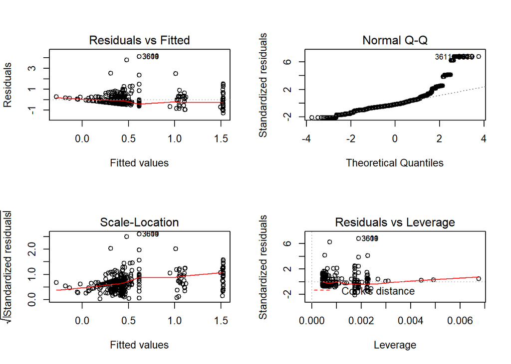

```r
par(mfrow=c(2,2))
plot(fit.abund.f)
```

Here is the right tail on the residuals:

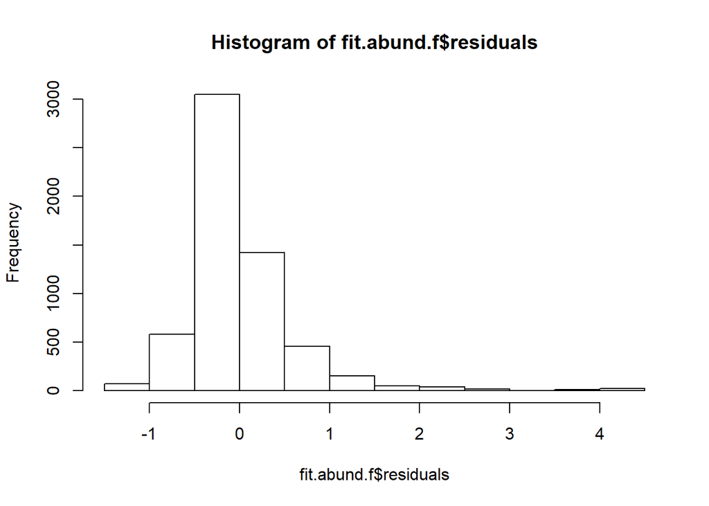

```r
hist(fit.abund.f$residuals)
```